# **Homework 4 Classification**

Enes Ata Oruç

29.01.2021

The aim of this homework is to compare the performance of penalized regression approaches, decision trees, support vector machines and tree-based ensembles. We are asked to find 4 datasets for a classification task from different domains. This report is created for Absenteeism Dataset.

### Absenteeism Data: (https://archive.ics.uci.edu/ml/datasets/Absenteeism+at+work)

```r
library(caTools)
library(randomForest)
library(ROCR)
library(tidyverse)
library(data.table)
library(rpart)
library(rattle)
library(rpart.plot)
library(RColorBrewer)
library(mlbench)
library(MLmetrics)
library(dplyr)
library(caret)
library(readr)
```

## 1. Penalized Regression Approach:

```r
absent <- fread("Absenteeism.csv")

library(glmnet)
absent$absent_hrs <- as.numeric(absent$absent_hrs)
smp_size_pra <- floor((2/3) * nrow(absent))

# set the seed to make your partition reproducible
set.seed(1234)
train_ind_pra <- sample(seq_len(nrow(absent)), size = smp_size_pra)

train_pra <- absent[train_ind_pra, ]
test_pra <- absent[-train_ind_pra, ]


absent_mat_2 <- data.matrix(train_pra)
cvfit=cv.glmnet(absent_mat_2, train_pra$absent_hrs,family='gaussian',nfolds=10)
cvfit
```

```
##
## Call:  cv.glmnet(x = absent_mat_2, y = train_pra$absent_hrs, nfolds = 10,      family = "gaussian")
##
## Measure: Mean-Squared Error
##
##     Lambda Measure      SE Nonzero
## min 0.3972  0.1717 0.04696       1
## 1se 0.4360  0.2047 0.05709       1
```

```r
lambda_min <- cvfit$lambda.min
lambda_min
```

```
## [1] 0.3972399
```

```r
# Lasso with Train Set
lassofit <- glmnet(x=absent_mat_2, y = train_pra$absent_hrs, alpha = 1,lambda = lambda_min)
lasso_train_predicted <-as.numeric(predict(lassofit, newx=data.matrix(train_pra)))

# RMSE for Train Lasso
caret::RMSE(lasso_train_predicted, train_pra$absent_hrs)
```

[output not shown]

```r
# Lasso with Test Set
lasso_test_predicted <-as.numeric(predict(lassofit, newx=data.matrix(test_pra)))
# RMSE for Test Lasso
caret::RMSE(lasso_test_predicted, test_pra$absent_hrs)
```

```
## [1] 0.3699911
```

## 2. Decision Tree Approach:

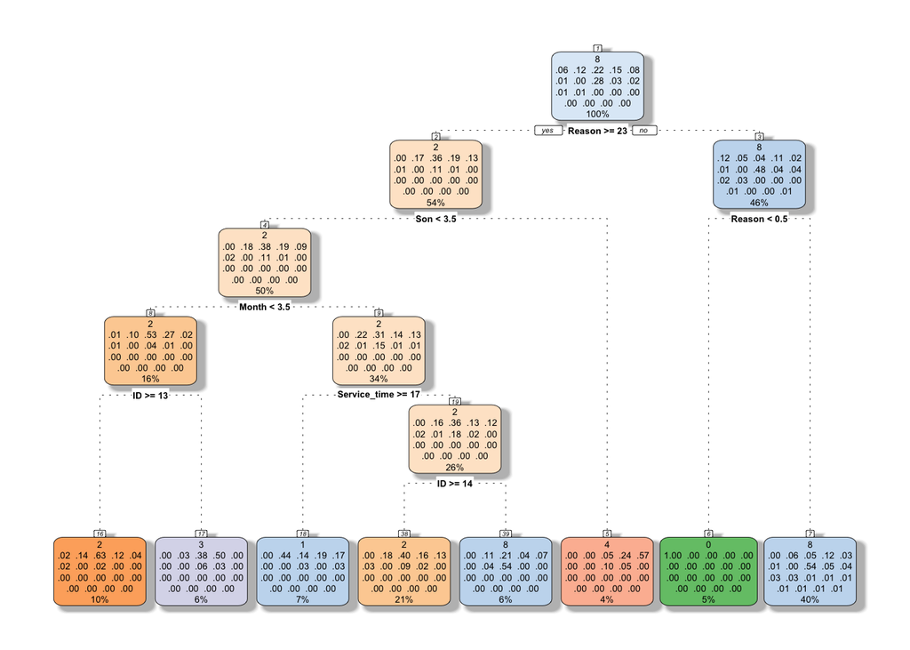

```r
# 75% of the sample size absent
absent$absent_hrs <- as.numeric(absent$absent_hrs)
smp_size_dt <- floor((2/3) * nrow(absent))

# set the seed to make your partition reproducible
set.seed(123)
train_ind_dt <- sample(seq_len(nrow(absent)), size = smp_size_dt)

train_dt_absent <- absent[train_ind_dt, ]
test_dt_absent <- absent[-train_ind_dt, ]

#method is "class" because I want to perform classification
mytree_absent <- rpart(
  absent_hrs ~ .,
  data = train_dt_absent,
  method = "class"
)

# plot mytree
fancyRpartPlot(mytree_absent, caption = NULL)
```

```r
printcp(mytree_absent) # display the results
```

```
##
## Classification tree:
## rpart(formula = absent_hrs ~ ., data = train_dt_absent, method = "class")
##
## Variables actually used in tree construction:
## [1] ID           Month        Reason       Service_time Son
##
## Root node error: 356/493 = 0.72211
##
## n= 493
##
##         CP nsplit rel error  xerror     xstd
## 1 0.185393      0   1.00000 1.00000 0.027939
## 2 0.075843      1   0.81461 0.81461 0.030695
## 3 0.030899      2   0.73876 0.73876 0.031115
## 4 0.015449      3   0.70787 0.72191 0.031157
## 5 0.011236      6   0.65169 0.71910 0.031162
## 6 0.010000      7   0.64045 0.71629 0.031166
```

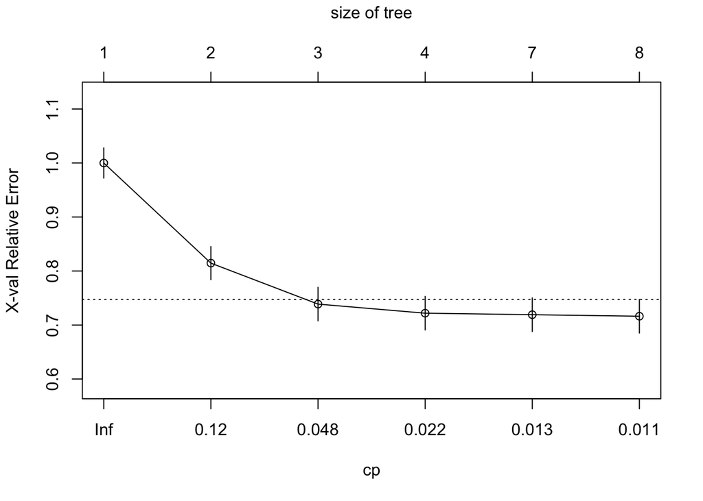

```r
plotcp(mytree_absent) # visualize cross-validation results
```

```r
summary(mytree_absent) # detailed summary of splits
```

```
## Call:
## rpart(formula = absent_hrs ~ ., data = train_dt_absent, method = "class")
##   n= 493
##
##           CP nsplit rel error    xerror       xstd
## 1 0.18539326      0 1.0000000 1.0000000 0.02793906
## 2 0.07584270      1 0.8146067 0.8146067 0.03069542
## 3 0.03089888      2 0.7387640 0.7387640 0.03111489
## 4 0.01544944      3 0.7078652 0.7219101 0.03115653
## 5 0.01123596      6 0.6516854 0.7191011 0.03116167
## 6 0.01000000      7 0.6404494 0.7162921 0.03116629
##
## Variable importance
##                 Reason   Disciplinary_failure                     ID
##                     35                     18                      7
##                    Son                    BMI       Distance_to_Work
##                      5                      5                      5
##           Service_time                  Month                 Weight
##                      4                      4                      4
## Transportation_expense                 Height              Work_load
##                      3                      2                      2
##                    Age             Hit_target                Seasons
##                      2                      1                      1
##                    Pet
##                      1
##
## Node number 1: 493 observations,    complexity param=0.1853933
##   predicted class=8  expected loss=0.7221095  P(node) =1
##     class counts:    28    57   106    75    40     6     1   137    14     9     5     6     1     1     1     2     1     1     2
##    probabilities: 0.057 0.116 0.215 0.152 0.081 0.012 0.002 0.278 0.028 0.018 0.010 0.012 0.002 0.002 0.002 0.004 0.002 0.002 0.004
##   left son=2 (268 obs) right son=3 (225 obs)
##   Primary splits:
##       Reason                 < 22.5    to the right, improve=34.179720, (0 missing)
##       Disciplinary_failure   < 0.5     to the right, improve=27.857090, (0 missing)
##       Transportation_expense < 229.5   to the left,  improve=10.151530, (0 missing)
##       Son                    < 1.5     to the left,  improve= 7.016316, (0 missing)
##       ID                     < 21.5    to the right, improve= 6.562177, (0 missing)
##   Surrogate splits:
##       Disciplinary_failure   < 0.5     to the left,  agree=0.594, adj=0.111, (0 split)
##       Transportation_expense < 226.5   to the left,  agree=0.588, adj=0.098, (0 split)
```

[output cut: 127 more lines]

```
##       Distance_to_Work       < 33.5    to the left,  agree=0.877, adj=0.429, (0 split)
##       Transportation_expense < 345.5   to the left,  agree=0.854, adj=0.321, (0 split)
##       Weight                 < 87      to the left,  agree=0.854, adj=0.321, (0 split)
##       BMI                    < 28.5    to the left,  agree=0.854, adj=0.321, (0 split)
##       Pet                    < 3       to the left,  agree=0.838, adj=0.250, (0 split)
##
## Node number 38: 102 observations
##   predicted class=2  expected loss=0.5980392  P(node) =0.2068966
##     class counts:     0    18    41    16    13     3     0     9     2     0     0     0     0     0     0     0     0     0     0
##    probabilities: 0.000 0.176 0.402 0.157 0.127 0.029 0.000 0.088 0.020 0.000 0.000 0.000 0.000 0.000 0.000 0.000 0.000 0.000 0.000
##
## Node number 39: 28 observations
##   predicted class=8  expected loss=0.4642857  P(node) =0.05679513
##     class counts:     0     3     6     1     2     0     1    15     0     0     0     0     0     0     0     0     0     0     0
##    probabilities: 0.000 0.107 0.214 0.036 0.071 0.000 0.036 0.536 0.000 0.000 0.000 0.000 0.000 0.000 0.000 0.000 0.000 0.000 0.000
```

```r
#prediction
predictions <- predict(mytree_absent, test_dt_absent, type = "class")
predictions = as.numeric(predictions)
# Prediction measures
table(test_dt_absent$absent_hrs, predictions)
```

```
##      predictions
##        1  2  3  4  5  8
##   0   16  0  0  0  0  0
##   1    0  7 12  1  0 11
##   2    0  7 27  7  0 10
##   3    0  4 13  7  3 10
##   4    0  3  6  0  2  9
##   5    0  0  1  0  0  0
##   8    0  4  5  3  0 59
##   16   0  0  0  0  0  5
##   24   0  0  0  0  0  7
##   32   0  0  0  0  0  1
##   40   0  0  0  0  0  1
##   56   0  0  0  0  0  1
##   64   0  0  0  0  0  2
##   80   0  0  0  0  0  1
##   112  0  0  0  0  0  1
##   120  0  0  0  0  0  1
```

```r
#RMSE Value for performance test
RMSE(test_dt_absent$absent_hrs,predictions)
```

```
## [1] 13.13647
```

## 3. Random Forest Approach on Absenteeism Dataset:

```r
#Random Forest Approach
absent$absent_hrs = as.numeric(absent$absent_hrs)
#Test/train split
smp_size <- floor((2/3) * nrow(absent))

# set the seed to make your partition reproducible
set.seed(1234)

train_ind <- sample(seq_len(nrow(absent)), size = smp_size)
train_rf <- absent[train_ind, ]
test_rf <- absent[-train_ind, ]
# randomize data
random_index <- sample(1:nrow(train_rf), nrow(train_rf))
random_rf_train <- train_rf[random_index, ]

# Fit random forest: model
# Set seed
set.seed(33)
# Fit a model
model <- train(absent_hrs~.,
               data = random_rf_train,
               method = "ranger",
               trControl = trainControl(method = "cv", number = 5)
                             )
# Let's check the model
model
```

```
## Random Forest
##
## 493 samples
##  20 predictor
##
## No pre-processing
## Resampling: Cross-Validated (5 fold)
## Summary of sample sizes: 393, 394, 395, 395, 395
## Resampling results across tuning parameters:
##
##   mtry  splitrule   RMSE      Rsquared   MAE
##    2    variance    12.33454  0.1772100  5.548747
##    2    extratrees  12.54857  0.1227917  5.758569
##   11    variance    12.42877  0.2022360  5.442614
##   11    extratrees  12.34589  0.1934774  5.407600
##   20    variance    12.84905  0.1839311  5.640765
##   20    extratrees  12.33034  0.2122642  5.350043
##
## Tuning parameter 'min.node.size' was held constant at a value of 5
## RMSE was used to select the optimal model using the smallest value.
## The final values used for the model were mtry = 20, splitrule = extratrees
##  and min.node.size = 5.
```

```r
fit <- predict(model, newdata = test_rf)
fit_model <- train(absent_hrs~.,
               data = test_rf,
               method = "ranger",
               trControl = trainControl(method = "cv", number = 5)
                            )
fit_model
```

```
## Random Forest
##
## 247 samples
##  20 predictor
##
## No pre-processing
## Resampling: Cross-Validated (5 fold)
## Summary of sample sizes: 198, 198, 198, 197, 197
## Resampling results across tuning parameters:
##
##   mtry  splitrule   RMSE      Rsquared   MAE
##    2    variance    11.66499  0.2016904  5.363358
##    2    extratrees  11.38321  0.2157871  5.152777
##   11    variance    12.05576  0.2144587  5.440707
##   11    extratrees  11.65620  0.2424954  5.274700
##   20    variance    12.22682  0.2160307  5.495170
##   20    extratrees  11.86620  0.2618251  5.372753
##
## Tuning parameter 'min.node.size' was held constant at a value of 5
## RMSE was used to select the optimal model using the smallest value.
## The final values used for the model were mtry = 2, splitrule = extratrees
##  and min.node.size = 5.
```

```r
test_rf$absent_hrs <- as.numeric(test_rf$absent_hrs)
# RMSE for measure error
RMSE(test_rf$absent_hrs,fit)
```

```
## [1] 11.90773
```

## 4. Stochastic Gradient Approach:

```r
library(gbm)
absent$absent_hrs = as.numeric(absent$absent_hrs)
#Test/train split
smp_size <- floor((2/3) * nrow(absent))

# set the seed to make your partition reproducible
set.seed(1234)

train_ind <- sample(seq_len(nrow(absent)), size = smp_size)
train_sgb <- absent[train_ind, ]
test_sgb <- absent[-train_ind, ]
# randomize data
random_index <- sample(1:nrow(train_sgb), nrow(train_sgb))
random_sgb_train <- train_sgb[random_index, ]

# modify hyperparameter grid
hyper_grid <- expand.grid(
  shrinkage = c(.01, .05, .1),
  interaction.depth = c(3, 5, 7),
  n.minobsinnode = c(5, 7, 10),
  bag.fraction = c(.65, .8, 1),
  optimal_trees = 0,               # a place to dump results
  min_RMSE = 0                     # a place to dump results
)

# total number of combinations
nrow(hyper_grid)
```

```
## [1] 81
```

```r
## [1] 81

# grid search
for(i in 1:nrow(hyper_grid)) {

  # reproducibility
  set.seed(123)

  # train model
  gbm.tune <- gbm(formula = absent_hrs ~ .,
    distribution = "gaussian",
    data = random_sgb_train,
    n.trees = 600,
    interaction.depth = hyper_grid$interaction.depth[i],
    shrinkage = hyper_grid$shrinkage[i],
    n.minobsinnode = hyper_grid$n.minobsinnode[i],
    bag.fraction = hyper_grid$bag.fraction[i],
    train.fraction = .75,
    n.cores = NULL, # will use all cores by default
    verbose = FALSE
  )

  # add min training error and trees to grid
  hyper_grid$optimal_trees[i] <- which.min(gbm.tune$valid.error)
  hyper_grid$min_RMSE[i] <- sqrt(min(gbm.tune$valid.error))
}

hyper_grid %>%
  dplyr::arrange(min_RMSE) %>%
  head(10)
```

```
##    shrinkage interaction.depth n.minobsinnode bag.fraction optimal_trees
## 1       0.10                 7              7         0.80             9
## 2       0.10                 7             10         0.80             9
## 3       0.10                 5             10         0.80             9
## 4       0.05                 7              7         0.65            18
## 5       0.10                 5              7         0.80             9
## 6       0.01                 7             10         0.65           119
## 7       0.01                 7              7         0.65           126
## 8       0.10                 7              7         0.65             8
## 9       0.05                 7              7         0.80            11
## 10      0.01                 7             10         0.80            90
##    min_RMSE
## 1  11.79528
## 2  11.92898
## 3  11.99068
## 4  12.00888
## 5  12.03562
## 6  12.06941
## 7  12.07891
## 8  12.07933
## 9  12.09052
## 10 12.09303
```

```r
# for reproducibility
set.seed(123)

# train GBM model
gbm.fit.final <- gbm(formula = absent_hrs ~ .,
  distribution = "gaussian",
  data = train_sgb,
  n.trees = 483,
  interaction.depth = 5,
  shrinkage = 0.1,
  n.minobsinnode = 5,
  bag.fraction = .65,
  train.fraction = 1,
  n.cores = NULL, # will use all cores by default
  verbose = FALSE
  )
# predict values for test data
pred <- predict(gbm.fit.final, n.trees = gbm.fit.final$n.trees, test_sgb)

# results
caret::RMSE(pred, test_sgb$absent_hrs)
```

```
## [1] 15.14108
```

## Compare Results

Penalized Regression Approach

```r
# RMSE for Test Lasso
caret::RMSE(lasso_test_predicted, test_pra$absent_hrs)
```

```
## [1] 0.3699911
```

Decision Tree Approach

```r
#RMSE Value for performance test DT
RMSE(test_dt_absent$absent_hrs,predictions)
```

```
## [1] 13.13647
```

Random Forest

```r
# RMSE Value for performance test
RMSE(test_rf$absent_hrs,fit)
```

```
## [1] 11.90773
```

Stochastic Gradient Boosting

```r
# results
caret::RMSE(pred, test_sgb$absent_hrs)
```

```
## [1] 15.14108
```

When we looked at the RMSE values I believe there is some miscalculation happened in lasso approach because its value doesn’t seem realistic. This lasso situation also happened on different datasets. But I tuned the other 3 approaches. Because of this meaningful assumptions, I believe they gave more reliable results.

So, when we consider the other approaches Random Forest gave the best classification result on Absenteeism data. There was a lot of different classes in Target colum (absent_hrs). This target column determined by the researches that provided this dataset.